# NEC-estimation examples

Rebecca Fisher,Gerard Ricardo and David Fox

04 December, 2019

## 0.1 Background

This document contains examples for running the NEC-estimation package ‘jagsNEC’ currently under development. This code is being worked up by Rebecca Fisher and Gerard Ricardo (AIMS), and David Fox (Environmentrics). The package is being developed at https://github.com/AIMS/NEC-estimation and is a No-Effect-Concentration (NEC) model specific wrapper for the R2jags package available in R. The NEC mode fit is based on the model described in (Fox 2010), althought we have generalised the package to allow a large range of response variables to be modelled using the appropriate statistical distribution.

Bayesian model fitting can be difficult to automate across a broad range of usage cases, particularly with respect to specifying valid initial values and appropriately vague priors. This is one reason the use of Bayesian statistics for NEC estimation is not currently widely adopted across the broader ecotoxicological community, who rarely have access to specialist statistical expertise. The jagsNEC package attempts to provide an accessible interface to the R2jags package specifically for fitting NEC models, with a range of models specified based on the known distribution of the “concentration” or “dose” variable (the predictor, x) as well as the “response” (y) variable. The model formula, including priors and the required init function required to call a jags model are automatically generated based on information contained in the supplied data. While the distribution of the x and y variables can be specified directly, jagsNEC will automatically ‘guess’ the correct distribution to use, based on the characteristics of the provided data. See ?write.jags.NECmod for the currently available x and y data types.

Inportant information on the current package is contained in the jagsNEC helpfile (see ?jagsNEC).

This package is currently under development. We are keen on any feedback regarding usage, and especially bug reporting that includes an easy self contained reproducible example of either unexpected behaviour or example model fits that fail to converge (have poor chain mixing) or yield other errors. Such information will hopefully help us towards building a more robust package. We cannot help troublshoot issues if an easy to run reproducible example is not supplied.

## 0.2 Package installation

With the R package ‘devtools’ jagsNEC can be installed straight from github. Once installed the library must be loaded (like any other R library), along with the R2jags library.

```r
#devtools::install_github("AIMS/NEC-estimation")
library(jagsNEC)
library(R2jags)
require(tidyverse)
```

## 0.3 Examples

Here we include some examples showing how to use the package to fit an NEC model to binomial, proportional, count and continuous response (y) data. The examples are those used by Gerard Ricardo at: https://github.com/gerard-ricardo/NECs/blob/master/NECs. Here we show how to run the same jags models using the jagsNEC wrapper package currently under development.

### 0.3.1 Binomial data

Where data are a count out of a total (such as the percentage survival of individuals, for example) y is binomial. First we read in the binomial example from pastebin, and then plot the “concentration” or x data, in this case raw.x.

```r
binom.data <-  read.table("https://pastebin.com/raw/zfrUha88", header= TRUE,dec=",")
str(binom.data)
```

```
## 'data.frame':    48 obs. of  3 variables:
##  $ raw.x: Factor w/ 8 levels "0.1","100","12.5",..: 1 1 1 1 1 1 8 8 8 8 ...
##  $ suc  : int  101 106 102 112 58 158 95 91 93 113 ...
##  $ tot  : int  175 112 103 114 69 165 109 92 99 138 ...
```

```r
binom.data$raw.x <- as.numeric(as.character(binom.data$raw.x))
range(binom.data$raw.x)
```

```
## [1]   0.1 400.0
```

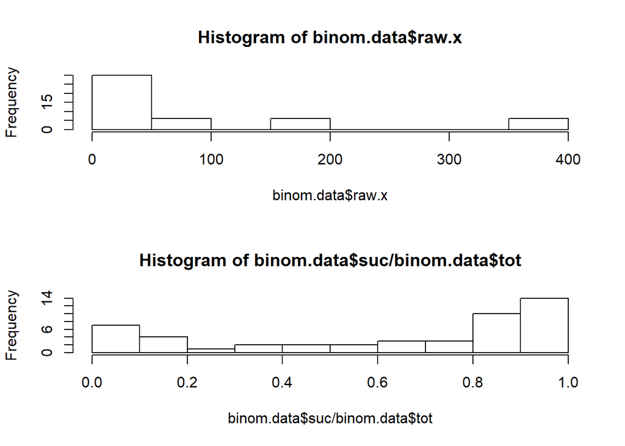

```r
par(mfrow=c(2,1))
hist(binom.data$raw.x)
hist(binom.data$suc/binom.data$tot)
```

In this case for x, lowest concentration is 0.1 and the highest is 400. The data are right skewed and on the continuous scale. This type of distribution for the x data are common for concentration response experiments, where the x “concentration” data are the concentration of contaminants, or dilutions. In general we can model x as gamma. The current default in jagsNEC is to estimate the appropriate distribution for both the *y.type* and *x.type* arguments, but it is possible to supply these arguments directly.

The data are clearly binomial, with the header “suc” - indicating the number of ‘successes’ in the binomial call, with ‘tot’ clearly indicating the number of trials.

The main ‘working’ function in jagsNEC is the function fit.jagsNEC, which calls the other necessary functions and fits the jags model. See ?fit.jagsNEC for more details. We run fit.jagsNEC by supplying *data* - a data.frame containing the data for the model fitting, here, binom.data; *x.var* - the name of the column in *data* which contains the concentration data or ‘x’ data to be used in the NEC model fit, and *y.var* - the name of the column in *data* which contains the response or ‘y’ data to be used in the NEC model fit. In our example here, as this is binomial, we must also supply *trials.var*, which is the name of the column in *data* which contains the number of trials in the binomial call.

fit.jagsNEC sill guess the data types for use, although we could specify *y.type* as “binomial” and *x.type* as “gamma”. This example fits without specifying either, but trials.var must be supplied.

```r
out <- fit.jagsNEC(data=binom.data,
                        x.var="raw.x",
                        y.var="suc",
                        trials.var="tot")
```

```
## module glm loaded
```

```
## Warning in fit.jagsNEC(data = binom.data, x.var = "raw.x", y.var = "suc", :
## The generated init.fun failed to yield a valid model. Model based on
## default jags initial values
```

```
## Response variable suc modelled using a binomial distribution.
```

The function shows the progress of the jags fit and returns the usual jags output (with a few other additions to this list). The function *check.chains* can be used to plot the chains and the chain ACF, so we can assess mixing and looks for other potential issues with the model fit. Initially jagsNEC will attempt to use starting values generated by the init function that we have specified for that type of model fit. It will run a small number of iterations and then test for good mixing. If the model fails to fit or the mixing is not very good (among chain variance is a lot bigger than within chain variance) jagsNEC with try up to *n.tries* more times to fit the data using the generated *init* function to try and obtain a successfuly fitted model with good mixing. If this still fails to yield a successful and/or well mixed model, jagsNEC will try up to *n.tries* more times using the default initial values as generated by R2jags. If no model is successfully fit an error will be returned indicating the model could not be fit succesfully. If a model is fit but still has poor mixing even after *n.tries* attempts, the model with the best mixing will be returned, with a warning to cautiously interpret the results and inspect the chain mixing diagnostic plot.

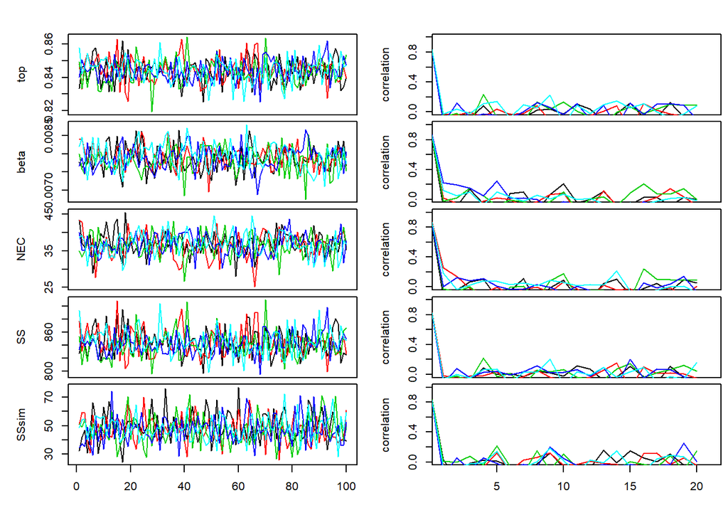

```r
check.chains(out)
```

In our example, the chains are well mixed and our ACF plot looks good, so we can go ahead and interpret this model.

The function *plot* can be used to plot the fitted model. Alternatively you can make your own plot from the data included in the returned list from the call to fit.jagsNEC. In this example, this could be extracted using *out$pred.vals*

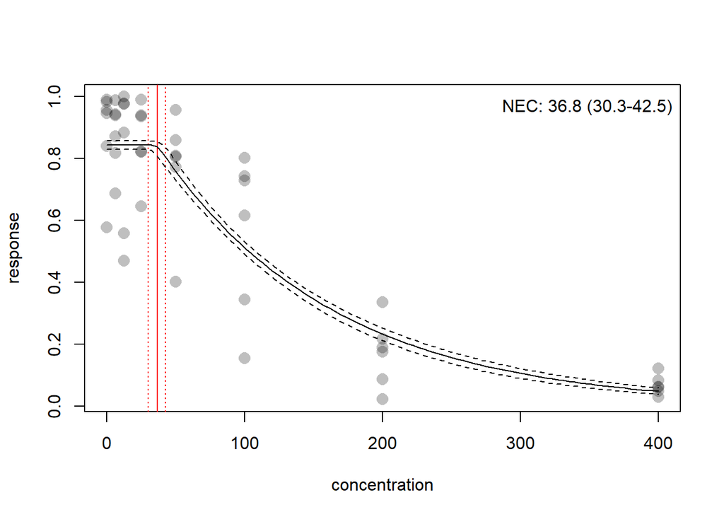

```r
par(mfrow=c(1,1))
plot(out)
```

### 0.3.2 Beta data

Sometimes the response variable is distributed between *0* and *1* but is not a straight forward binomial. A common example in coral ecology is maximum quantum yield (the proportion of light used for photosynthesis when all reaction centres are open) which is a measure of photosynthetic efficiency calculated from PAM data. Here we have a proportion value that is not based on trials and successes. In this case there are no theoretical ‘trials’ and the data must be modelled using a beta distribution.

```r
prop.data <- read.table("https://pastebin.com/raw/123jq46d", header= TRUE,dec=",") %>%
  mutate(raw.x=log(as.numeric(as.character(raw.x))+1),
         resp=as.numeric(as.character(resp)))
out <- fit.jagsNEC(data=prop.data,
                   x.var="raw.x",
                   y.var="resp",
                   n.tries=1)
```

```
##
## Deleting model
```

```
##
## Deleting model
##
##
```

```
## Response variable resp modelled using a beta distribution.
```

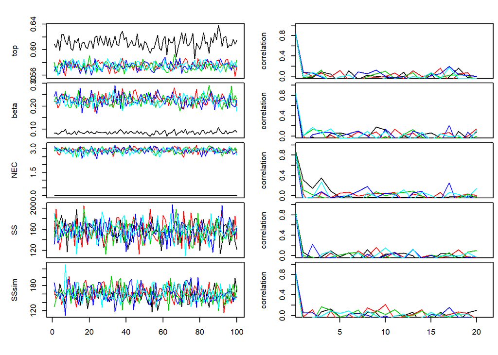

```r
check.chains(out)
```

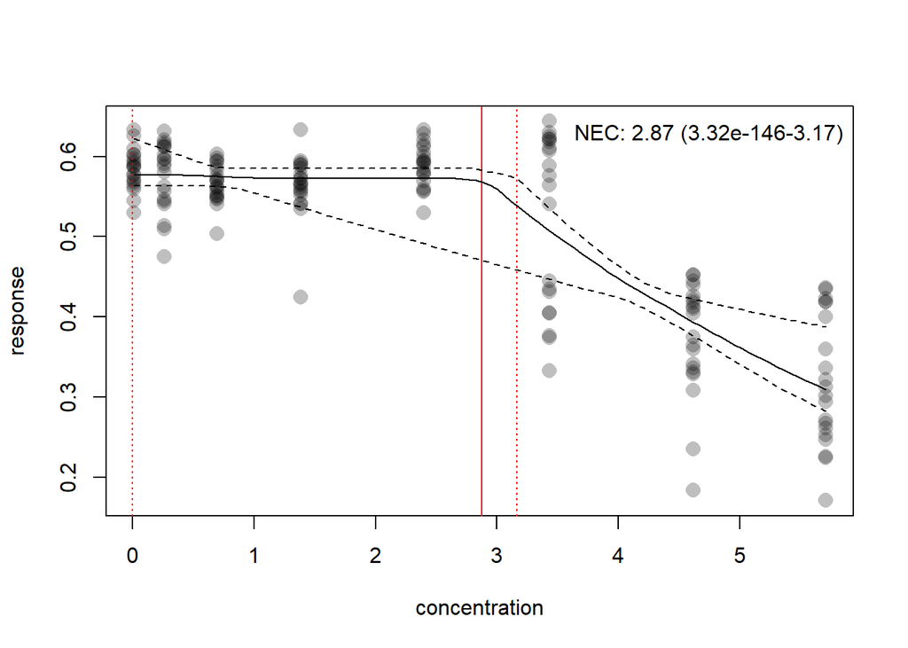

```r
par(mfrow=c(1,1))
plot(out)
```

### 0.3.3 Poisson data

Where data are a count (of, for example, individuals or cells) y is poisson. Such data are distributed from *0* to *Inf* and are integers. First we read in the count data example from pastebin, and then plot the “concentration” or x data, Again, this is raw.x, and distributed as in our binomial example above.

```r
count.data = read.table("https://pastebin.com/raw/ENgNSgf7", header= TRUE,dec=",")
str(count.data)
```

```
## 'data.frame':    48 obs. of  2 variables:
##  $ raw.x: Factor w/ 8 levels "0.1","101","12",..: 1 1 1 1 1 1 8 8 8 8 ...
##  $ count: int  164 100 103 102 102 101 131 102 112 100 ...
```

```r
count.data$raw.x <- as.numeric(as.character(binom.data$raw.x))

range(count.data$raw.x)
```

```
## [1]   0.1 400.0
```

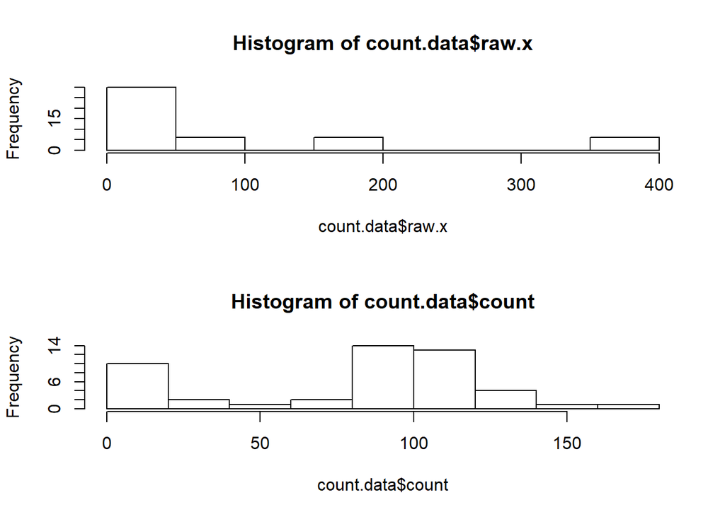

```r
par(mfrow=c(2,1))
hist(count.data$raw.x)
hist(count.data$count)
```

First we supply *fit.jagsNEC* with *data* (count.data), and specify *x.var* and *y.var*. As we have concentration data, our *x.type* would be the gamma distribution, and *y.type* is “poisson”. The default behaviour to guess the variable types works for this example.

```r
out <- fit.jagsNEC(data=count.data,
                        x.var="raw.x",
                        y.var="count")
```

```
## Response variable count modelled using a poisson distribution.
```

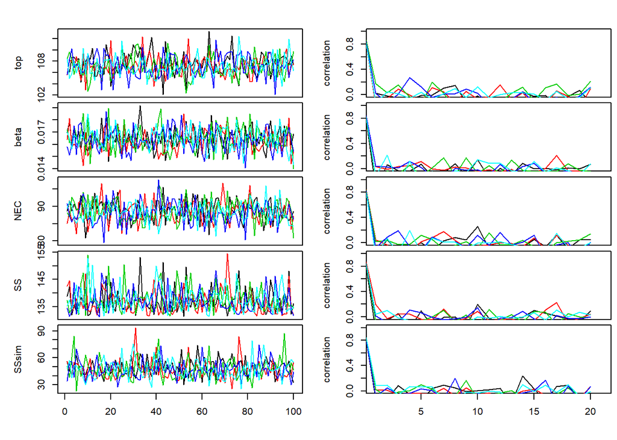

```r
check.chains(out)
```

In our example, the chains are well mixed and our ACF plot looks good, we we can go ahead and interpret this model.

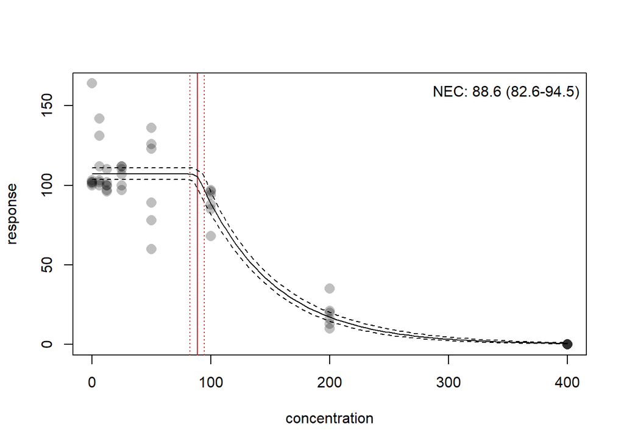

```r
par(mfrow=c(1,1))
plot(out)
```

### 0.3.4 Measure data

```r
measure.data = read.table("https://pastebin.com/raw/pWeS6x0n", header= TRUE,dec=",")
measure.data$raw.x <- as.numeric(as.character(measure.data$raw.x))
measure.data$measure <- as.numeric(as.character(measure.data$measure))
```

```r
out <- fit.jagsNEC(data=measure.data,
                   x.var="raw.x",
                   y.var="measure")
```

```
##
## Deleting model
```

[output not shown]

```
## Response variable measure modelled using a gamma distribution.
```

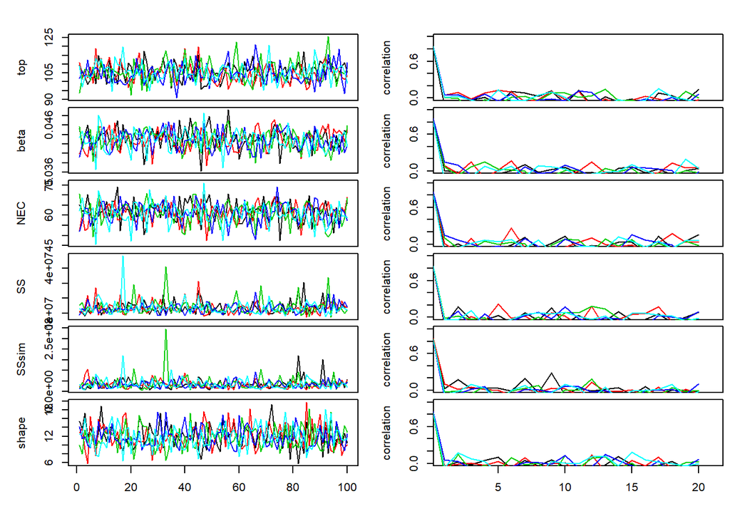

```r
check.chains(out)
```

The function *plot* can be used to plot the fitted model.

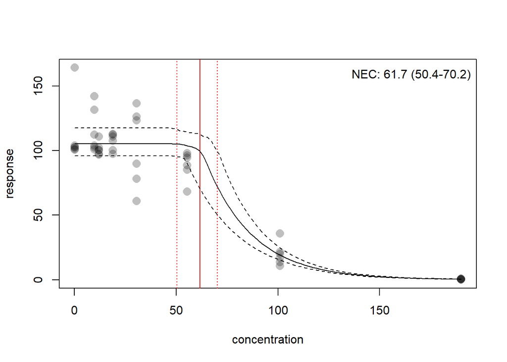

```r
par(mfrow=c(1,1))
plot(out)
```

### References

Fox, David R. 2010. “A Bayesian approach for determining the no effect concentration and hazardous concentration in ecotoxicology.” *Ecotoxicology and Environmental Safety* 73 (2): 123–31.